# A1: Exploration and Cleaning of Dataset

Michelle Lin

15 Feb 2024

## SET UP

```r
# Set up and Install all Libraries if not present

if (!requireNamespace("BiocManager", quietly = TRUE))
    install.packages("BiocManager")

if (!requireNamespace("GEOquery", quietly = TRUE))
    install.packages("GEOquery")

if (!requireNamespace("knitr", quietly = TRUE))
    install.packages("knitr")

if (!requireNamespace("edgeR", quietly = TRUE))
    install.packages("edgeR")

if (!requireNamespace("hrbrthemes", quietly = TRUE))
    install.packages("hrbrthemes")

if (!requireNamespace("ggplot2", quietly = TRUE))
    install.packages("ggplot2")

if (!requireNamespace("ComplexHeatmap", quietly = TRUE))
    install.packages("ComplexHeatmap")

if (!requireNamespace("circlize", quietly = TRUE))
    install.packages("circlize")
```

### Set Global variables and constants

```r
# Set GEOID
GEOID <- "GSE160230"
conditions <- c("Mock", "Mock", "Mock", "Control", "Control", "Control", "GWTreated", "GWTreated", "GWTreated")

## File location
workingDir <- file.path(getwd())
```

## SUMMARY OF NORMALISATION ON RESULTS FROM A1

The study used is “hPSC-derived Airway Organoids-based Screen Reveals the Role of HIF1/ Glycolysis Axis in SARS-CoV-2 Infection” published in 2021 by Duan et al.(Duan et al. 2021)

The authors conducted a study in human pluripotent stem cell (hPSC) derived airway organoids - (hPSC-AO) where they studied the molecular mechanism behind SARS-Cov-2 infections and the differential expression of different components of the pathways when treated with GW6571. There were 9 samples and 3 conditions compared: 3 mock samples (untreated and uninfected), 3 control samples (untreated and SARS-Cov2 infected), 3 GW-treated samples (treated with GW6571 and infected with SARS-Cov2).

For this project, the original down-sampled RNA-seq data set was used for analysis. Downsampling was done on the mock and GW-treated samples by the authors Duan et al, to allow for comparability amongst the three conditions. This is because there was a significantly lower human gene count captured in the control samples due to the high viral counts. This dataset was then pre-processed and matched using Ensembl Gene Identifiers, filtered for low expression and then normalised. The final resulting data set has 14671 genes for the 9 samples as mentioned above.

### Running A1 and importing relevant files

```r
# Render notebook 1
rmarkdown::render("../A1new/A1_MichelleLin_new.Rmd")
```

[output not shown]

```r
## import the normalised data

### Note: imported object is a large matrix with rows as genes and columns as samples
# normalisedCounts <- readRDS("../A1new/NormalisedData.RDS")
# cleanData <- readRDS("../A1new/N")

normalisedCounts <- normalised
cleanData <- cleanData

## create a separate data frame to indicate the conditions tested
samples <- c("Mock1", "Mock2", "Mock3", "Control1", "Control2", "Control3", "GW-Treated1", "GW-Treated2", "GW-Treated3")

sample_condition <- data.frame(
  Sample = samples,
  Condition = conditions
)
```

## DIFFERENTIAL GENE EXPRESSION

### MDS Plots from A1

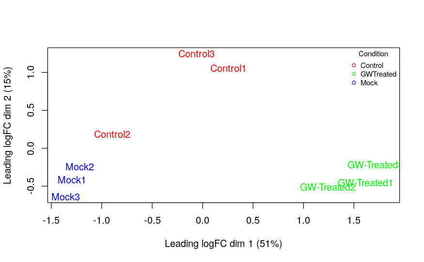

```r
## MDS PLOT
limma::plotMDS(log2(normalisedCounts), labels=colnames(normalisedCounts), pch=5,
               col = c("red", "green", "blue")[factor(conditions)])

legend("topright",
  legend=levels(factor(conditions)),
  pch=c(1), col= c("red", "green","blue"),title="Condition",
  bty = 'n', cex = 0.75)
```

From the above, we can see clustering according to the sample type / condition and thus, this will be the factor of interest in our study for differential gene expression. As this is a relatively simple data set, this will be the only factor of interest in our model moving forward.

### Analysis & Hypothesis Testing using EdgeR

```r
## Create a Design Matrix
designMatrix <- model.matrix(~conditions)
print(designMatrix)
```

```
  (Intercept) conditionsGWTreated conditionsMock
1           1                   0              1
2           1                   0              1
3           1                   0              1
4           1                   0              0
5           1                   0              0
6           1                   0              0
7           1                   1              0
8           1                   1              0
9           1                   1              0
attr(,"assign")
[1] 0 1 1
attr(,"contrasts")
attr(,"contrasts")$conditions
[1] "contr.treatment"
```

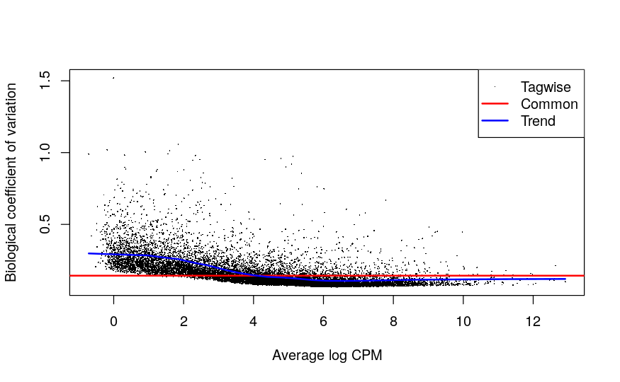

```r
# create the DGE object using the filtered and cleaned raw counts dataset
formDGE = edgeR::DGEList(counts=cleanData, group = conditions)
formDGE <- edgeR::calcNormFactors(formDGE)

# estimate dispersion using our model design
formDGE <- edgeR::estimateDisp(formDGE, designMatrix)

edgeR::plotBCV(formDGE, )
```

```r
fit <- edgeR::glmQLFit(formDGE,
                       designMatrix)

head(fit$coefficients, 6)
```

```
         (Intercept) conditionsGWTreated conditionsMock
A1BG-AS1   -12.12381          0.01383095     0.06629683
A1CF       -10.32953         -0.01820233     0.04537535
A2M        -10.59827          0.39651847     0.41654491
A2M-AS1    -13.25305         -0.30003198    -0.24088520
A2ML1      -12.82960         -0.97630755    -0.82019270
A4GALT     -11.27065          0.08773355    -0.39217614
```

### Pairwise contrasts for all conditions

For this test, a cutoff significance value of 5% was used to find genes that showed differential expression as this was what was suggested and used by the paper. That is, for genes to be identified as statistically significant, there is less that 5% chance of getting this differential expression randomly. A significance cutoff of 5% is also the usual standard.

For the volcano plots, an absolute Fold Change greater 1 and signficance less than 0.05 was used to determine whether the genes are diffrentially expressed and of interest for pathway analysis later.

#### Control vs Treated

```r
## control vs treated
qlf.control_vs_treated <- edgeR::glmQLFTest(fit,
                                  coef = 2)

qlf_output_hits <- edgeR::topTags(qlf.control_vs_treated,
                                  sort.by = "PValue",
                                  n = nrow(normalisedCounts)
                                  )

length(which(qlf_output_hits$table$PValue < 0.05))
```

```
[1] 6354
```

```r
length(which(qlf_output_hits$table$FDR < 0.05))
```

```
[1] 4637
```

From the above comparison of control vs treated conditions, it resulted in 6354 significantly DE genes and 4637 significantly DE genes after correction, both using a significance cutoff of 0.05. The top 6 differentially expressed genes are shown:

|  | logFC | logCPM | F | PValue | FDR |
| --- | --- | --- | --- | --- | --- |
| ASNS | 2.806686 | 6.522208 | 1560.8163 | 0 | 0.0e+00 |
| ADM2 | 2.853202 | 5.148516 | 1017.7351 | 0 | 2.0e-07 |
| CHAC1 | 3.726479 | 4.975982 | 808.4367 | 0 | 4.0e-07 |
| SHMT2 | 1.461225 | 7.123998 | 580.5885 | 0 | 1.2e-06 |
| PCK2 | 2.186650 | 6.686168 | 564.7842 | 0 | 1.2e-06 |
| MTHFD2 | 1.531768 | 6.569194 | 550.7599 | 0 | 1.2e-06 |

|  | x |
| --- | --- |
| 1 | BH |

|  | x |
| --- | --- |
| 1 | conditionsGWTreated |

|  | x |
| --- | --- |
| 1 | glm |

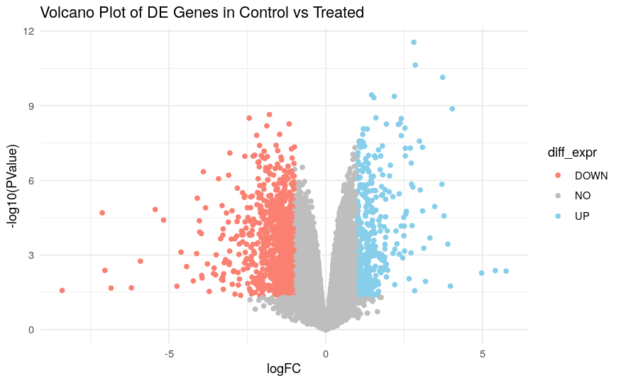

```r
## Volcano Plot

deDF <- as.data.frame(qlf_output_hits$table)
deDF$diff_expr <- "NO"

# if log2Foldchange > 1 and pvalue < 0.05, set as "UP"
deDF$diff_expr[deDF$logFC > 1 & deDF$PValue < 0.05] <- "UP"

# if log2Foldchange < -0.6 and pvalue < 0.05, set as "DOWN"
deDF$diff_expr[deDF$logFC < -1 & deDF$PValue < 0.05] <- "DOWN"

## Add labels for diffrentially expressed genes
deDF$label <- NA
deDF$label[deDF$diff_expr != "NO"] <- rownames(deDF)[deDF$diff_expr != "NO"]


ggplot(data=deDF, aes(x=logFC, y=-log10(PValue), col=diff_expr)) +
    geom_point() +
    theme_minimal() +
    scale_color_manual(values=c("salmon", "grey", "skyblue")) +
    ggtitle("Volcano Plot of DE Genes in Control vs Treated")
```

```r
# # create matrix
# heatmapMat <- normalisedCounts[,4:ncol(normalisedCounts)]
#
# # subset data for top hits
# topHits <- rownames(qlf_output_hits$table)[qlf_output_hits$table$PValue<0.05]
# heatmapMatTop <- t(scale(t(heatmapMat[which(rownames(heatmapMat)
#                                                      %in% topHits),])))
#
#
# # set heatmap colour scale
# if(min(heatmapMatTop) == 0){
#   heatmapCol = circlize::colorRamp2(c( 0, max(heatmapMatTop)),
#                            c( "white", "red"))
# } else {
#   heatmapCol = circlize::colorRamp2(c(min(heatmapMatTop), 0, max(heatmapMatTop)),
#                           c("blue", "white", "red"))
# }
#
#
# # define colours and annotations
# uniqCond <- unique("Control", "GWTreated")
# uniqCondCol <- rainbow(n = length(uniqCond))
# names(uniqCondCol) <- uniqCond
#
# annotations <- c("Control", "Control", "Control", "GWTreated", "GWTreated", "GWTreated")
#
# ha_pat <- ComplexHeatmap::HeatmapAnnotation(df = data.frame(x=colnames(heatmapMatTop), y=annotations),
#                                             col = list(condition = uniqCondCol),
#                                             show_legend = TRUE)
#
#
# # generate heatmap
# ComplexHeatmap::Heatmap(as.matrix(heatmapMatTop),
#                         top_annotation = ha_pat,
#                         cluster_rows = TRUE,
#                         cluster_columns = TRUE,
#                         show_row_dend = TRUE,
#                         show_column_dend = TRUE,
#                         col=heatmapCol,
#                         show_column_names =FALSE,
#                         show_row_names = FALSE,
#                         show_heatmap_legend = TRUE,
#                         column_title = ("Top hits across samples"))
```

#### Control vs Mock

```r
## control vs mock
qlf.control_vs_mock <- edgeR::glmQLFTest(fit,
                                  coef = 3)

qlf_output_hits <- edgeR::topTags(qlf.control_vs_mock,
                           sort.by = "PValue",
                           n = nrow(normalisedCounts))

length(which(qlf_output_hits$table$PValue < 0.05))
```

```
[1] 1854
```

```r
length(which(qlf_output_hits$table$FDR < 0.05))
```

```
[1] 207
```

From the above comparison of control vs mock conditions, it resulted in 1854 significantly DE genes and 207 significantly DE genes after correction, both using a significance cutoff of 0.05. The top 6 differentially expressed genes are shown:

|  | logFC | logCPM | F | PValue | FDR |
| --- | --- | --- | --- | --- | --- |
| EGR1 | -4.5518236 | 6.702269 | 141.77914 | 3.0e-07 | 0.0047823 |
| CXCL10 | -3.6217753 | 4.893323 | 101.43102 | 1.5e-06 | 0.0087593 |
| NR4A1 | -2.8780814 | 6.347983 | 93.60158 | 2.2e-06 | 0.0087593 |
| SLFN5 | -0.7678011 | 5.818472 | 90.20919 | 2.6e-06 | 0.0087593 |
| REL | -1.3613680 | 4.191521 | 82.85759 | 3.8e-06 | 0.0087593 |
| PDE4D | -1.0417286 | 5.326746 | 80.93381 | 4.3e-06 | 0.0087593 |

|  | x |
| --- | --- |
| 1 | BH |

|  | x |
| --- | --- |
| 1 | conditionsMock |

|  | x |
| --- | --- |
| 1 | glm |

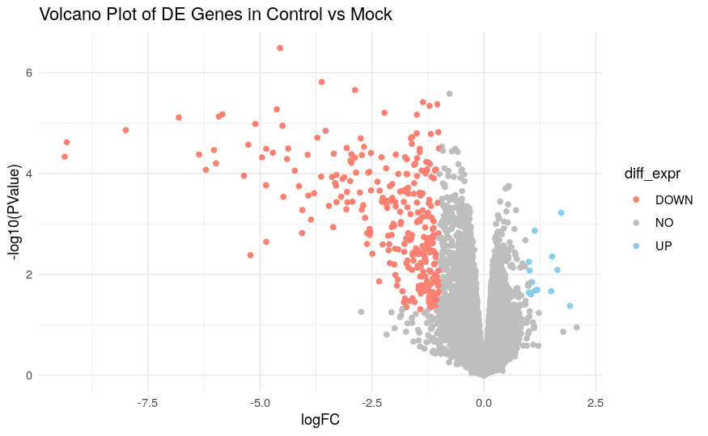

```r
## Volcano Plot

deDF <- as.data.frame(qlf_output_hits$table)
deDF$diff_expr <- "NO"

# if log2Foldchange > 1 and pvalue < 0.05, set as "UP"
deDF$diff_expr[deDF$logFC > 1 & deDF$PValue < 0.05] <- "UP"

# if log2Foldchange < -0.6 and pvalue < 0.05, set as "DOWN"
deDF$diff_expr[deDF$logFC < -1 & deDF$PValue < 0.05] <- "DOWN"

## Add labels for diffrentially expressed genes
deDF$label <- NA
deDF$label[deDF$diff_expr != "NO"] <- rownames(deDF)[deDF$diff_expr != "NO"]


ggplot(data=deDF, aes(x=logFC, y=-log10(PValue), col=diff_expr)) +
    geom_point() +
    theme_minimal() +
    scale_color_manual(values=c("salmon", "grey", "skyblue")) +
    ggtitle("Volcano Plot of DE Genes in Control vs Mock")
```

#### Treated vs Mock

```r
## treated vs mock
qlf.treated_vs_mock <- edgeR::glmQLFTest(fit, contrast=c(0,-1,1))

qlf_output_hits <- edgeR::topTags(qlf.treated_vs_mock,
                           sort.by = "PValue",
                           n = nrow(normalisedCounts))

length(which(qlf_output_hits$table$PValue < 0.05))
```

```
[1] 6341
```

```r
length(which(qlf_output_hits$table$FDR < 0.05))
```

```
[1] 4768
```

From the above comparison of treated vs mock conditions, it resulted in 6341 significantly DE genes and 4768 significantly DE genes after correction, both using a significance cutoff of 0.05. The top 6 differentially expressed genes are shown:

|  | logFC | logCPM | F | PValue | FDR |
| --- | --- | --- | --- | --- | --- |
| ASNS | -2.808754 | 6.522208 | 1559.5689 | 0 | 0.0e+00 |
| ADM2 | -2.750124 | 5.148516 | 955.5877 | 0 | 2.0e-07 |
| CHAC1 | -3.719709 | 4.975982 | 803.9624 | 0 | 4.0e-07 |
| MTHFD2 | -1.581977 | 6.569194 | 584.4479 | 0 | 1.3e-06 |
| PCK2 | -2.125304 | 6.686168 | 536.0290 | 0 | 1.6e-06 |
| SHMT2 | -1.371348 | 7.123998 | 513.8936 | 0 | 1.6e-06 |

|  | x |
| --- | --- |
| 1 | BH |

|  | x |
| --- | --- |
| 1 | -1*conditionsGWTreated 1*conditionsMock |

|  | x |
| --- | --- |
| 1 | glm |

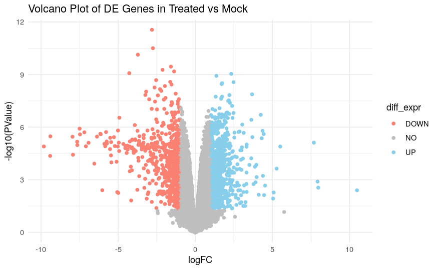

```r
## Volcano Plot

deDF <- as.data.frame(qlf_output_hits$table)
deDF$diff_expr <- "NO"

# if log2Foldchange > 1 and pvalue < 0.05, set as "UP"
deDF$diff_expr[deDF$logFC > 1 & deDF$PValue < 0.05] <- "UP"

# if log2Foldchange < -0.6 and pvalue < 0.05, set as "DOWN"
deDF$diff_expr[deDF$logFC < -1 & deDF$PValue < 0.05] <- "DOWN"

## Add labels for diffrentially expressed genes
deDF$label <- NA
deDF$label[deDF$diff_expr != "NO"] <- rownames(deDF)[deDF$diff_expr != "NO"]


ggplot(data=deDF, aes(x=logFC, y=-log10(PValue), col=diff_expr)) +
    geom_point() +
    theme_minimal() +
    scale_color_manual(values=c("salmon", "grey", "skyblue")) +
    ggtitle("Volcano Plot of DE Genes in Treated vs Mock ")
```

#### Differential Expression amongst all conditions

```r
# differential expression amongst all
qlf <- edgeR::glmQLFTest(fit, coef=2:3)
knitr::kable(edgeR::topTags(qlf),
      type="html",
      row.names =TRUE)
```

|  | logFC.conditionsGWTreated | logFC.conditionsMock | logCPM | F | PValue | FDR |
| --- | --- | --- | --- | --- | --- | --- |
| ASNS | 2.806686 | -0.0020684 | 6.522208 | 1265.4518 | 0 | 0.0e+00 |
| ADM2 | 2.853202 | 0.1030784 | 5.148516 | 795.9007 | 0 | 1.0e-07 |
| CHAC1 | 3.726479 | 0.0067698 | 4.975982 | 677.2355 | 0 | 1.0e-07 |
| PCK2 | 2.186650 | 0.0613459 | 6.686168 | 429.9186 | 0 | 6.0e-07 |
| MTHFD2 | 1.531768 | -0.0502086 | 6.569194 | 425.4945 | 0 | 6.0e-07 |
| SHMT2 | 1.461225 | 0.0898766 | 7.123998 | 406.8783 | 0 | 6.0e-07 |
| CYP1A1 | 4.033386 | -0.2488325 | 9.523279 | 406.1076 | 0 | 6.0e-07 |
| STC2 | 2.405976 | -0.1342752 | 5.904540 | 308.8141 | 0 | 2.0e-06 |
| EIF4EBP1 | 1.596871 | -0.0275321 | 5.647744 | 286.6876 | 0 | 2.6e-06 |
| SLC3A2 | 1.931743 | -0.0405627 | 9.303467 | 263.1257 | 0 | 3.2e-06 |

|  | x |
| --- | --- |
| 1 | BH |

|  | x |
| --- | --- |
| 1 | conditionsGWTreated |
| 2 | conditionsMock |

|  | x |
| --- | --- |
| 1 | glm |

```r
qlf_output_hits_overall <- edgeR::topTags(qlf,
                           sort.by = "PValue",
                           n = nrow(normalisedCounts))

length(which(qlf_output_hits_overall$table$PValue < 0.05))
```

```
[1] 6598
```

```r
length(which(qlf_output_hits_overall$table$FDR < 0.05))
```

```
[1] 4940
```

From the above comparison of conditions, it resulted in 6598 significantly DE genes and 4940 significantly DE genes after correction, both using a significance cutoff of 0.05. The top 6 differentially expressed genes are shown:

|  | logFC.conditionsGWTreated | logFC.conditionsMock | logCPM | F | PValue | FDR |
| --- | --- | --- | --- | --- | --- | --- |
| ASNS | 2.806686 | -0.0020684 | 6.522208 | 1265.4518 | 0 | 0e+00 |
| ADM2 | 2.853202 | 0.1030784 | 5.148516 | 795.9007 | 0 | 1e-07 |
| CHAC1 | 3.726479 | 0.0067698 | 4.975982 | 677.2355 | 0 | 1e-07 |
| PCK2 | 2.186650 | 0.0613459 | 6.686168 | 429.9186 | 0 | 6e-07 |
| MTHFD2 | 1.531768 | -0.0502086 | 6.569194 | 425.4945 | 0 | 6e-07 |
| SHMT2 | 1.461225 | 0.0898766 | 7.123998 | 406.8783 | 0 | 6e-07 |

|  | x |
| --- | --- |
| 1 | BH |

|  | x |
| --- | --- |
| 1 | conditionsGWTreated |
| 2 | conditionsMock |

|  | x |
| --- | --- |
| 1 | glm |

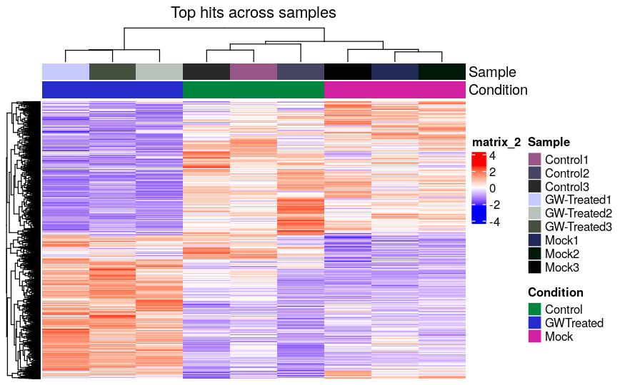

```r
# create matrix
heatmapMat <- normalisedCounts

# subset data for top hits
topHits <- rownames(qlf_output_hits_overall$table)[qlf_output_hits_overall$table$PValue<0.05]
heatmapMatTop <- t(scale(t(heatmapMat[which(rownames(heatmapMat) %in% topHits),])))


# set heatmap colour scale
if(min(heatmapMatTop) == 0){
  heatmapCol = circlize::colorRamp2(c( 0, max(heatmapMatTop)),
                           c( "white", "red"))
} else {
  heatmapCol = circlize::colorRamp2(c(min(heatmapMatTop), 0, max(heatmapMatTop)),
                          c("blue", "white", "red"))
}


# define colours and annotations
uniqCond <- unique(conditions)
uniqCondCol <- rainbow(n = length(uniqCond))
names(uniqCondCol) <- uniqCond

ha_pat <- ComplexHeatmap::HeatmapAnnotation(df = data.frame(sample_condition),
                                            col = list(condition = uniqCondCol),
                                            show_legend = TRUE)


# generate heatmap
ComplexHeatmap::Heatmap(as.matrix(heatmapMatTop),
                        top_annotation = ha_pat,
                        cluster_rows = TRUE,
                        cluster_columns = TRUE,
                        show_row_dend = TRUE,
                        show_column_dend = TRUE,
                        col=heatmapCol,
                        show_column_names =FALSE,
                        show_row_names = FALSE,
                        show_heatmap_legend = TRUE,
                        column_title = ("Top hits across samples"))
```

From the above HeatMap, it is observed that the control and mock samples are clustered together compared to the GW-treated sample. This is also reinforced in the initial MDS plot where the control and mock samples are closer together than the treated samples.

## THRESHOLD OVER-REPRESENTATION ANALYSIS

### Over Representation Analysis

From the above, we can try running analysis on the control vs treated samples for over-representation analysis as a result of differential expression in these samples.

```r
# note top hits
ctrl_trt_top <- edgeR::topTags(qlf.control_vs_treated, n = nrow(normalisedCounts))

# number of upregulated genes
numUp <- length(which(ctrl_trt_top$table$PValue < 0.05 & ctrl_trt_top$table$logFC > 1))

numDown <- length(which(ctrl_trt_top$table$PValue < 0.05 & ctrl_trt_top$table$logFC < -1))
```

Using thresholds as suggested by the paper for pathway analysis absolute logFC of 1 and significance at 5%, it was found that there were 383 up regulated genes and 905 down regulated genes.

```r
# Create non-thresholded list of genes
qlfDF <- as.data.frame(ctrl_trt_top$table)
qlfDF$Gene <- rownames(qlfDF)
qlfDF$Rank <- log(qlfDF$PValue,base =10) * sign(qlfDF$logFC)
qlfDF <- qlfDF[order(qlfDF$Rank),]

# write to table and save
write.table(x=data.frame(genename=qlfDF$Gene,
                         F_stat= qlfDF$Rank),
            file=file.path(getwd(),"treated_vs_control_nonthreshold.txt"),
            sep = "\t",
            row.names = FALSE,
            col.names = FALSE,
            quote = FALSE)

# Create thresholded list of genes
upregulated_genes <- qlfDF$Gene[which(qlfDF$PValue < 0.05 & qlfDF$logFC > 1)]
downregulated_genes <- qlfDF$Gene[which(qlfDF$PValue < 0.05 & qlfDF$logFC < -1)]


write.table(x=upregulated_genes,
            file=file.path(getwd(),"upregulated_genes.txt"),
            sep = "\t",
            row.names = FALSE,
            col.names = FALSE,
            quote = FALSE)

write.table(x=downregulated_genes,
            file=file.path(getwd(),"downregulated_genes.txt"),
            sep = "\t",
            row.names = FALSE,
            col.names = FALSE,
            quote = FALSE)
```

```r
## for both up and down regulated
query_set <- c(upregulated_genes, downregulated_genes)
bothRes <- gprofiler2::gost(query = query_set ,
                          significant=FALSE,
                          ordered_query = FALSE,
                          exclude_iea=TRUE,
                          correction_method = "fdr",
                          organism = "hsapiens",
                          source = c("REAC","WP","GO:BP"))

# GProfiler results
bothEnrRes <- bothRes$result
bothEnrResTop <- bothRes$result[bothRes$result$p_value < 0.05,]
bothEnrResTop[1:5,]
```

|  | query | significant | p_value | term_size | query_size | intersection_size | precision | recall | term_id | source | term_name | effective_domain_size | source_order | parents |
| --- | --- | --- | --- | --- | --- | --- | --- | --- | --- | --- | --- | --- | --- | --- |
| 1 | query_1 | TRUE | 1.263008e-27 | 790 | 1064 | 146 | 0.13721805 | 0.1848101 | GO:0000278 | GO:BP | mitotic cell cycle | 16178 | 77 |  |
| 2 | query_1 | TRUE | 6.060589e-26 | 654 | 1064 | 127 | 0.11936090 | 0.1941896 | GO:1903047 | GO:BP | mitotic cell cycle process | 16178 | 23301 |  |
| 3 | query_1 | TRUE | 2.584990e-21 | 250 | 1064 | 68 | 0.06390977 | 0.2720000 | GO:0140014 | GO:BP | mitotic nuclear division | 16178 | 20198 |  |
| 4 | query_1 | TRUE | 2.984229e-20 | 1119 | 1064 | 164 | 0.15413534 | 0.1465594 | GO:0022402 | GO:BP | cell cycle process | 16178 | 6830 |  |
| 5 | query_1 | TRUE | 3.364817e-20 | 1429 | 1064 | 193 | 0.18139098 | 0.1350595 | GO:0007049 | GO:BP | cell cycle | 16178 | 2680 |  |

```r
NA
```

There were 1083 significant pathway hits using a significance of 5%, some of which are shown above. From the above table, the top pathway hits involved mitotic cell cycles.

### Up-regulated set of genes analysis

```r
## for up-reg

upregRes <- gprofiler2::gost(query = upregulated_genes,
                          significant=FALSE,
                          ordered_query = FALSE,
                          exclude_iea=TRUE,
                          correction_method = "fdr",
                          organism = "hsapiens",
                          source = c("REAC","WP","GO:BP"))

# GProfiler results
upregEnrRes <- upregRes$result
upregEnrResTop <- upregRes$result[upregRes$result$p_value < 0.05,]
upregEnrResTop[1:5,]
```

|  | query | significant | p_value | term_size | query_size | intersection_size | precision | recall | term_id | source | term_name | effective_domain_size | source_order | parents |
| --- | --- | --- | --- | --- | --- | --- | --- | --- | --- | --- | --- | --- | --- | --- |
| 1 | query_1 | TRUE | 2.752502e-15 | 228 | 286 | 31 | 0.1083916 | 0.13596491 | GO:0051607 | GO:BP | defense response to virus | 16178 | 14278 |  |
| 2 | query_1 | TRUE | 7.526746e-12 | 334 | 286 | 32 | 0.1118881 | 0.09580838 | GO:0009615 | GO:BP | response to virus | 16178 | 3578 |  |
| 3 | query_1 | TRUE | 7.526746e-12 | 925 | 286 | 54 | 0.1888112 | 0.05837838 | GO:0098542 | GO:BP | defense response to other organism | 16178 | 19336 |  |
| 4 | query_1 | TRUE | 1.344464e-11 | 1350 | 286 | 66 | 0.2307692 | 0.04888889 | GO:0006952 | GO:BP | defense response | 16178 | 2614 |  |
| 5 | query_1 | TRUE | 2.437251e-11 | 844 | 286 | 50 | 0.1748252 | 0.05924171 | GO:0140546 | GO:BP | defense response to symbiont | 16178 | 20385 |  |

```r
NA
```

It was found that there were 320 significant pathways, some of which are shown above. From the above table, the top pathway hits involved defense mechanism which are involved in immune response to viral infections - SARS-Cov2.

### Down-regulated set of genes analysis

```r
## for down-reg
downregRes <- gprofiler2::gost(query = downregulated_genes,
                          significant=FALSE,
                          ordered_query = FALSE,
                          exclude_iea=TRUE,
                          correction_method = "fdr",
                          organism = "hsapiens",
                          source = c("REAC","WP","GO:BP"))

# GProfiler results
downregEnrRes <- downregRes$result
downregEnrResTop <- downregRes$result[downregRes$result$p_value < 0.05,]
downregEnrResTop[1:5,]
```

|  | query | significant | p_value | term_size | query_size | intersection_size | precision | recall | term_id | source | term_name | effective_domain_size | source_order | parents |
| --- | --- | --- | --- | --- | --- | --- | --- | --- | --- | --- | --- | --- | --- | --- |
| 1 | query_1 | TRUE | 9.610968e-40 | 790 | 778 | 140 | 0.1799486 | 0.1772152 | GO:0000278 | GO:BP | mitotic cell cycle | 16178 | 77 |  |
| 2 | query_1 | TRUE | 2.372952e-37 | 654 | 778 | 123 | 0.1580977 | 0.1880734 | GO:1903047 | GO:BP | mitotic cell cycle process | 16178 | 23301 |  |
| 3 | query_1 | TRUE | 3.042862e-33 | 1119 | 778 | 158 | 0.2030848 | 0.1411975 | GO:0022402 | GO:BP | cell cycle process | 16178 | 6830 |  |
| 4 | query_1 | TRUE | 5.167108e-32 | 1429 | 778 | 180 | 0.2313625 | 0.1259622 | GO:0007049 | GO:BP | cell cycle | 16178 | 2680 |  |
| 5 | query_1 | TRUE | 9.645409e-30 | 250 | 778 | 68 | 0.0874036 | 0.2720000 | GO:0140014 | GO:BP | mitotic nuclear division | 16178 | 20198 |  |

There were 1173 significant pathways using a signifcance threshold of 0.05. The down-regulated genes seem to be involved in mitotic cell processes and could potentially have overwhelmed the upregulated genes in the combined results as there are significantly more down-regulated genes than upregulated genes (905:383 respectively).

### Visualisations

The top 5 hits in each category of enrichment analysis were as follows:

| Both | Upregulated | DownRegulated |
| --- | --- | --- |
| mitotic cell cycle | defense response to virus | mitotic cell cycle |
| mitotic cell cycle process | response to virus | mitotic cell cycle process |
| mitotic nuclear division | defense response to other organism | cell cycle process |
| cell cycle process | defense response | cell cycle |
| cell cycle | defense response to symbiont | mitotic nuclear division |

## CONCLUSION

This analysis does provide some support to the results in the paper. In the paper, it was mentioned that GW-treated had resulted in a decreased expression in chemokines - which was also present in our analysis after taking a look at the down-regulated genes. However, what was different in this analysis compared to the paper’s was that in this analysis, it was found that up-regulated genes were involved in defense mechanisms whereas the paper found that GW-treatment did not have much of an impact on the interferon pathway - involved in defense against pathogens. Some more analysis can potentially be done to compare infected vs non-infected as well.

## BIBLIOGRAPHY

Duan, Xiaohua, Xuming Tang, Manoj S Nair, Tuo Zhang, Yunping Qiu, Wei Zhang, Pengfei Wang, et al. 2021. “An Airway Organoid-Based Screen Identifies a Role for the HIF1$\alpha$-Glycolysis Axis in SARS-CoV-2 Infection.” *Cell Reports* 37 (6).